# Entrega grupal

Víctor Gonzalez (DNI: 72220012-N), Jorge Polo (DNI: 70428525-H), Izan Díaz (DNI: 02556291-W), Alejandro Jiménez (DNI: 71321278-A), Yeray Benito (DNI:06655579-T)

## Instrucciones

- Modificad dentro del documento .qmd vuestros datos personales (nombre y DNI) que se encuentran en el encabezado del archivo.
- Aseguraos de que el archivo .qmd se renderice correctamente ANTES de continuar editando el documento y que el archivo .html correspondiente se genere en tu carpeta local en el ordenador.

## Instrucciones

- Los bloques de código (chunks) creados están vacíos o incompletos. Una vez que edites lo que consideres necesario, debes cambiar cada bloque a #| eval: true (o eliminarlo directamente) para que se ejecuten.
- Recuerda que puedes ejecutar los bloques de código uno por uno con el botón play o ejecutar todos los bloques hasta un bloque específico (con el botón situado a la izquierda del anterior).

## Paquetes necesarios

> Insertad aquí todos los paquetes vayáis necesitando

```r
rm(list = ls())
library(tidyverse)
library(lubridate)
library(glue)
library(sf)
library(mapSpain)
```

## Entrega grupal

### Datos

Un viejo amigo: la práctica se basará en los **archivos de datos electorales** que se indican a continuación, recopilando datos sobre las elecciones al Congreso de los Diputados en España desde 2008 hasta la actualidad, así como encuestas, códigos de municipios y abreviaturas

```r
# NO TOQUES NADA
election_data <- read_csv(file = "../data/data/datos_elecciones_brutos.csv")
cod_mun <- read_csv(file = "../data/data/cod_mun.csv")
surveys <- read_csv(file = "../data/data/historical_surveys.csv")
abbrev <- read_csv(file = "../data/data/siglas.csv")
```

## Datos

- `election_data`: archivo con las elecciones al congreso
- `cod_mun`: archivo con los códigos y nombres de cada municipio
- `abbrev`: siglas de cada partido
- `surveys`: encuestas electorales desde 1982.

## Datos

- `surveys`: encuestas electorales desde 1982.
  - `type_survey`: tipo de encuesta (nacional, regional…)
  - `date_elec`: fecha de las futuras elecciones
  - `id_pollster`, `pollster`, `media`: id y nombre de la empresa encuestadora, así como medio que la encargó
  - `field_date_from`, `field_date_to`: fechas de inicio y fin del trabajo de la encuesta
  - `exit_poll`: ¿es una encuesta a pie de urna?
  - `size`: tamaño muestral de la encuesta
  - `turnout`: participación (estimación)

## Objetivos

El objetivo de la entrega es **realizar un análisis de los datos electorales**, llevando a cabo la depuración, los resúmenes y los gráficos que consideres necesarios, tanto de los resultados como de la precisión de las encuestas electorales.

En concreto, debes trabajar únicamente en el **período de tiempo que incluye las elecciones desde 2008 hasta las últimas elecciones de 2019**

# Introducción

El contexto de este proyecto consiste en realizar un análisis que nos permita estudiar las tendencias y resultados claves. En este estudio nos enfrentamos a datos en bruto.

El objetivo de este análisis fue limpiar y estructurar estos datos desde 2008 hasta 2019 y responder preguntas clave utilizando el programa R.

# Metodología

## Contexto de los datos

Hemos tratado inicialmente con dos fuentes de datos principales:

- **datos_elecciones_brutos.csv**
- **historical_surveys.csv**

### Problemas iniciales:

- Datos inconsistentes.
- Valores duplicados.
- Nombres redundantes de partidos.

## Proceso de limpieza

1. Normalización de nombres de partidos.
2. Transformación a tidy data.
3. Filtrado por fechas relevantes.
4. Eliminación de encuestas no válidas.

```r
partidos_a_filtrar <- c("PARTIDO SOCIALISTA OBRERO ESPAÑOL", "PSOE",
                        "PARTIDO POPULAR",
                        "CIUDADANOS", "C'S",
                        "PARTIDO NACIONALISTA VASCO", "EAJ-PNV",
                        "BLOQUE NACIONALISTA GALLEGO", "BNG",
                        "CONVERGÈNCIA I UNIÓ", "CDC",
                        "UNIDAS PODEMOS", "IU", "PODEM", "EZKER BATUA",
                        "ESQUERRA REPUBLICANA DE CATALUNYA", "ERC",
                        "EH - BILDU", "SORTU", "EUSKO ALKARTASUNA",
                        "ALTERNATIBA", "ARALAR",
                        "MÁS PAÍS", "VOX")


filtrado <- abbrev |>
  filter(str_detect(denominacion, str_c(partidos_a_filtrar, collapse = "|"))) |>
  mutate(siglas = case_when(
    str_detect(denominacion, "PARTIDO SOCIALISTA OBRERO ESPAÑOL|PSOE") ~ "PSOE",
    str_detect(denominacion, "PARTIDO POPULAR|PP") ~ "PP",
    str_detect(denominacion, "CIUDADANOS|C'S") ~ "CIUDADANOS",
    str_detect(denominacion, "PARTIDO NACIONALISTA VASCO|EAJ-PNV") ~ "PNV",
    str_detect(denominacion, "BLOQUE NACIONALISTA GALLEGO|BNG") ~ "BNG",
    str_detect(denominacion, "CONVERGÈNCIA I UNIÓ|CDC") ~ "CIU",
    str_detect(denominacion, "UNIDAS PODEMOS|EZKER BATUA|IU|PODEM") ~ "UNIDAS PODEMOS",
    str_detect(denominacion, "ESQUERRA REPUBLICANA DE CATALUNYA|ERC") ~ "ERC",
    str_detect(denominacion, "EH-BILDU|SORTU|EUSKO ALKARTASUNA|ARALAR|ALTERNATIBA") ~ "EH-BILDU",
    str_detect(denominacion, "MÁS PAÍS") ~ "MÁS PAÍS",
    str_detect(denominacion, "VOX") ~ "VOX"
  )) |>
    distinct(denominacion, siglas, .keep_all = TRUE)
```

```r
tidy_surveys<-
  surveys |>
  pivot_longer(cols = -c(type_survey : turnout), names_to= "partidos",
               values_to = "count", values_drop_na = TRUE)
tidy_surveys<- tidy_surveys |>
  filter(date_elec>= "2008-01-01") |>
  select(-type_survey)
tidy_surveys<- tidy_surveys |>
  left_join(filtrado, by = c("partidos" = "siglas")) |>
  mutate(partido = if_else(partidos %in% filtrado$siglas, partidos, "OTROS")) |>
  select(-partidos) |>
  relocate(partido, .before = turnout)
tidy_surveys <- tidy_surveys |>
  group_by(
    date_elec,       # Fecha de la elección
    id_pollster,     # Identificador de la casa encuestadora
    pollster,        # Nombre de la casa encuestadora
    media,           # Medio asociado
    partido         # Partido (incluyendo "OTROS")
  ) |>
  summarise(
    count = sum(count, na.rm = TRUE),   # Sumar votos por partido
    field_date_from = first(field_date_from),  # Duración del trabajo de campo (igual para todas las filas de una encuesta)
    field_date_to = first(field_date_to),
    exit_poll = first(exit_poll),      # Si es o no encuesta a pie de urna (debe ser igual dentro del grupo)
    size = first(size),                # Tamaño muestral
    turnout = first(turnout),          # Participación estimada
    .groups = "drop"                   # Eliminar niveles de agrupación
  )
tidy_surveys<- tidy_surveys |>
  filter(exit_poll!= TRUE) |>
  filter(!is.na(size) & size >= 500) |>
  select(-exit_poll)
tidy_surveys<- tidy_surveys |>
  mutate(field_duration = ymd(field_date_to) - ymd(field_date_from)) |>
  filter(field_duration > 1) |>
  select(-c(field_date_from, field_date_to)) |>
  relocate(field_duration, .after = media)
```

```r
datos_elecciones_tidy <- election_data |>
  pivot_longer(
    cols = -c(tipo_eleccion, anno, mes, vuelta, codigo_ccaa, codigo_provincia, codigo_municipio,
              codigo_distrito_electoral, numero_mesas, censo, participacion_1, participacion_2,
              votos_blancos, votos_nulos, votos_candidaturas),
    names_to = "partido",
    values_to = "votos"
  ) |>
  left_join(filtrado, by = c("partido" = "denominacion")) |>
  mutate(partido = coalesce(siglas, "OTROS")) |>
  group_by(tipo_eleccion, anno, mes, vuelta, codigo_ccaa, codigo_provincia, codigo_municipio, partido, censo) |>
  summarise(votos = sum(votos, na.rm = TRUE), .groups = "drop") |>
  filter(votos > 0) |>  # Eliminar partidos con 0 votos
  filter(across(everything(), ~ !is.na(.))) |>  # Eliminar valores NA
    mutate(
    codigo_municipio = glue::glue("{codigo_ccaa}-{codigo_provincia}-{codigo_municipio}")) |> # Crear el nuevo codigo_municipio en formato xx-xx-xxx
  left_join(cod_mun, by= c("codigo_municipio"="cod_mun")) |>  # Hacer join con cod_mun para agregar el nombre del municipio
  select(-codigo_ccaa, -codigo_provincia)

# Seleccionar columnas relevantes y ajustar datos
datos_elecciones_tidy <- datos_elecciones_tidy |>
  select(where(~ n_distinct(.) > 1)) |> # Eliminar columnas constantes
  mutate(mes = as.numeric(mes)) # Convertir mes a formato numérico
```

## Datos finales

Los datos finales están limpios y listos para el análisis.

# Análisis de Preguntas

## Pregunta 1: ¿Qué partido fue el ganador en los municipios con más de 100,000 habitantes (censo) en cada una de las elecciones?

```r
# Filtrar los municipios con un censo mayor a 100,000 habitantes
municipios_grandes <- datos_elecciones_tidy |>
  filter(censo > 100000)

# Crear una columna combinada de eleccion (año y mes) para agrupar más fácilmente
# Utilizamos el paquete lubridate para gestionar las fechas si fuera necesario
municipios_grandes <- municipios_grandes |>
  mutate(eleccion = glue::glue("{anno}-{mes}"))

totales_municipio <- municipios_grandes |>
  group_by(eleccion, codigo_municipio) |>
  summarise(votos_totales_municipio = sum(votos, na.rm = TRUE), .groups = "drop")

# 5. Agregar el total de votos por municipio a la tabla original
municipios_grandes <- municipios_grandes |>
  left_join(totales_municipio, by = c("eleccion", "codigo_municipio"))

municipios_grandes <- municipios_grandes |>
  mutate(porcentaje_votos = (votos / votos_totales_municipio) * 100)

# 7. Agrupar por elección, municipio y partido para calcular votos y porcentajes
resumen_votos <- municipios_grandes |>
  group_by(eleccion, codigo_municipio, partido,municipio,censo) |>
  summarise(
    votos_totales = sum(votos, na.rm = TRUE),
    porcentaje_votos = sum(porcentaje_votos, na.rm = TRUE),
    .groups = "drop"
  )

partidos_ganadores <- resumen_votos |>
  group_by(eleccion, codigo_municipio) |>
  slice_max(porcentaje_votos, n = 1, with_ties = FALSE) |>
  ungroup()

# Elegimos los colores de cada partido
colores_partidos <- c(
  "BNG" = "#FF5733",
  "CIUDADANOS" = "#FFC300",
  "EH-BILDU" = "#DAF7A6",
  "ERC" = "#FF33FF",
  "MÁS PAÍS" = "#33FF57",
  "OTROS" = "#8C8C8C",
  "PNV" = "#33DFFF",
  "PP" = "#0000FF",
  "PSOE" = "#FF0000",
  "UNIDAS PODEMOS" = "#800080",
  "VOX" = "#008000"
)

partidos_ganadores |>
  ggplot(aes(x = as.factor(codigo_municipio), y = porcentaje_votos, fill = partido)) +
  geom_bar(stat = "identity", position = position_dodge(width = 0.9), color = "black", size = 0.2) + # Bordes negros finos para separar las barras
  facet_wrap(~ eleccion, scales = "free_x") +
  labs(
    title = "Partidos Ganadores por Municipio y Elección",
    subtitle = "Porcentaje de votos por partido en municipios seleccionados",
    x = "Código de Municipio",
    y = "Porcentaje de Votos",
    fill = "Partido"
  ) +
  scale_x_discrete(breaks = function(x) x[seq(1, length(x), by = 13)]) +  # Mostrar cada 13 municipios para evitar sobrecarga
  scale_fill_manual(values = colores_partidos) +
  theme_minimal(base_size = 12) + # Tamaño base de texto ajustado
  theme(
    axis.text.x = element_text(angle = 90, hjust = 1, vjust = 0.5, size = 7), # Rotación vertical con ajuste
    axis.title.x = element_text(size = 10, face = "bold"),
    axis.title.y = element_text(size = 10, face = "bold"),
    strip.text = element_text(size = 10, face = "bold"), # Facetas más claras y en negrita
    plot.title = element_text(size = 16, face = "bold", hjust = 0.5), # Título centrado y destacado
    plot.subtitle = element_text(size = 12, hjust = 0.5), # Subtítulo centrado
    legend.position = "right", # Leyenda en la parte inferior para aprovechar el espacio
    legend.title = element_text(face = "bold"),
    legend.text = element_text(size = 9)
  ) +
  scale_y_continuous(labels = scales::percent_format(scale = 1)) # Mostrar porcentaje en eje Y
```

[figure not shown]

# Código y gráfica relacionada

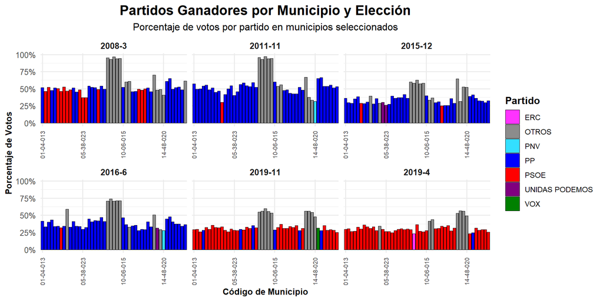

## Pregunta 2: ¿Qué partido fue el segundo cuando el primero fue el PSOE? ¿Y cuando el primero fue el PP?

```r
# Creamos una columna combinada de eleccion (año y mes) para agrupar más fácilmente
datos_elecciones_tidy <- datos_elecciones_tidy |>
  mutate(eleccion = glue::glue("{anno}-{mes}"))

#Agrupamos por eleccion, municipio y partido, y sumar los votos
resumen_votos <- datos_elecciones_tidy |>
  group_by(eleccion, codigo_municipio, partido) |>
  summarise(votos_totales = sum(votos, na.rm = TRUE), .groups = "drop")

# Determinar el partido ganador y el segundo lugar en cada municipio para cada eleccion
resultados <- resumen_votos |>
  group_by(eleccion, codigo_municipio) |>
  arrange(desc(votos_totales)) |>
  mutate(ranking = row_number()) |>   # Añadimos un ranking según los votos
  ungroup()

# Filtramos los partidos que quedaron en primer y segundo lugar
primeros_segundos <- resultados |>
  filter(ranking <= 2) |>
  filter(!is.na(partido)) |>
  group_by(eleccion, codigo_municipio) |>
  pivot_wider(names_from = ranking, values_from = c(partido, votos_totales), names_prefix = "ranking_") %>%
  ungroup()

#GRAFICOS
# Filtramos de nuevo según el ganador (PSOE o PP)
segundos_por_ganador <- primeros_segundos |>
  filter(partido_ranking_1 %in% c("PSOE", "PP")) |>
  group_by(partido_ranking_1, partido_ranking_2) |>
  summarise(
    veces_segundo = n(),
    .groups = "drop") |>
  group_by(partido_ranking_1) |>   # Normalizar los porcentajes por cada ganador
  mutate(porcentaje = (veces_segundo / sum(veces_segundo)) * 100) |>
  ungroup()

# Ajustar los valores de texto y espacios para evitar cortes
grafico2 <- segundos_por_ganador |>
  ggplot(aes(x = "", y = porcentaje, fill = partido_ranking_2)) +
  geom_bar(stat = "identity", width = 1, size = 0.5) +
  coord_polar("y", start = 0) +
  facet_wrap(~ partido_ranking_1, ncol = 2) +
  labs(
    title = "Partidos en Segundo Lugar por Ganador (PSOE vs PP)",
    subtitle = "Distribución del segundo lugar según el ganador",
    fill = "Partido en Segundo Lugar",
    x = NULL,
    y = NULL,
  ) +
  scale_fill_manual(values = colores_partidos) +  # Aplicar los colores personalizados
  theme_minimal(base_size = 14) + # Tamaño de fuente base
  theme(
    plot.title = element_text(face = "bold", size = 16, hjust = 0.5), # Título centrado y en negrita
    plot.subtitle = element_text(size = 12, hjust = 0.5), # Subtítulo centrado
    axis.text.x = element_blank(),
    axis.ticks = element_blank(),
    panel.grid = element_blank(),
    legend.position = "bottom", # Leyenda debajo para más espacio
    legend.title = element_text(face = "bold", size = 10), # Título de leyenda más grande
    legend.text = element_text(size = 10), # Texto de leyenda ajustado
    strip.text = element_text(face = "bold", size = 14) # Texto de facetas en negrita
  ) +
  guides(fill = guide_legend(nrow = 2, byrow = TRUE)) # Leyenda en 2 filas para mejor ajuste
```

# Código y gráfica relacionada

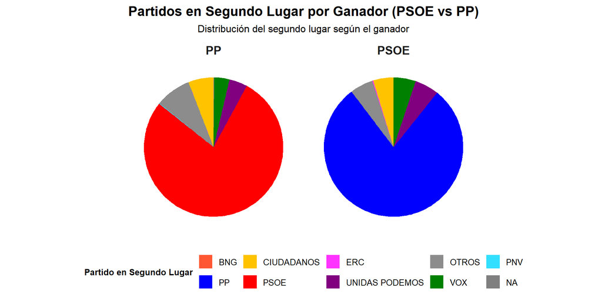

## Pregunta 3: ¿A quién beneficia la baja participación?

```r
# Calcular la participación por municipio
participacion_municipio <- datos_elecciones_tidy |>
  group_by(codigo_municipio, anno, mes) |>   # Ajustar nombres según los encontrados
  summarise(
    total_votos = sum(votos, na.rm = TRUE),
    censo_total = unique(censo),  # Ajustar si es necesario
    participacion = total_votos / censo_total * 100,
    .groups = "drop"
  )

# Calcular el porcentaje de votos por partido
votos_por_partido <- datos_elecciones_tidy |>
  group_by(codigo_municipio, anno, mes, partido) |>
  summarise(
    total_votos_partido = sum(votos, na.rm = TRUE),
    .groups = "drop"
  ) |>
  left_join(participacion_municipio, by = c("codigo_municipio", "anno", "mes")) |>
  group_by(codigo_municipio, anno, mes) |>
  summarise(
    partido = partido,
    porcentaje_votos = total_votos_partido / sum(total_votos_partido) * 100,  # Porcentaje por partido
    participacion = first(participacion),  # Tomar participación calculada previamente
    .groups = "drop"
  )

# Calcular el coeficiente de correlación entre participación y porcentaje de votos por partido
correlacion_por_partido <- votos_por_partido |>
  group_by(partido) |>
  summarise(
    correlacion = cor(participacion, porcentaje_votos, use = "complete.obs"),  # Correlación
    .groups = "drop"
  )

# Crear categorías de participación
votos_por_partido <- votos_por_partido |>
  mutate(
    nivel_participacion = case_when(
      participacion < 50 ~ "Baja",
      participacion >= 50 & participacion < 70 ~ "Media",
      participacion >= 70 ~ "Alta"
    )
  )

# Promediar votos por nivel de participación y partido
votos_niveles <- votos_por_partido |>
  group_by(nivel_participacion, partido) |>
  summarise(
    promedio_votos = mean(porcentaje_votos, na.rm = TRUE),
    .groups = "drop"
  )

#GRAFICAS
# Definir colores distinguibles para cada partido
colores_partidos <- c(
  "BNG" = "#FF5733",
  "CIUDADANOS" = "#FFC300",
  "EH-BILDU" = "#DAF7A6",
  "ERC" = "#FF33FF",
  "MÁS PAÍS" = "#33FF57",
  "OTROS" = "#8C8C8C",
  "PNV" = "#33DFFF",
  "PP" = "#0000FF",
  "PSOE" = "#FF0000",
  "UNIDAS PODEMOS" = "#800080",
  "VOX" = "#008000"
)

# Gráfico mejorado sin etiquetas numéricas
ggplot(votos_niveles, aes(x = nivel_participacion, y = promedio_votos, group = partido, color = partido)) +
  geom_line(size = 1.2) +  # Líneas más gruesas
  geom_point(size = 3) +  # Puntos más visibles
  scale_color_manual(values = colores_partidos) +  # Aplicar colores definidos
  labs(
    title = "Porcentaje de Votos por Partido según Nivel de Participación",
    x = "Nivel de Participación",
    y = "Porcentaje de Votos (%)",
    color = "Partido"
  ) +
  theme_minimal() +
  theme(
    plot.title = element_text(size = 12, face = "bold", hjust = 0.5),
    legend.title = element_text(size = 10),
    legend.text = element_text(size = 10),
    axis.title = element_text(size = 12),
    axis.text = element_text(size = 10))
```

[figure not shown]

# Código y gráfica relacionada

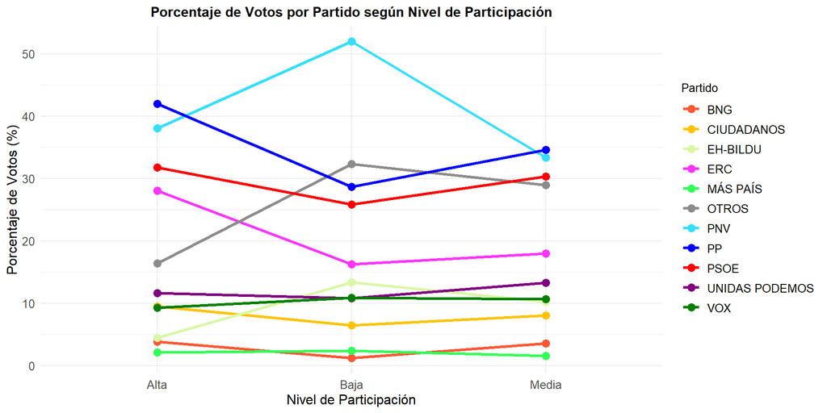

## Pregunta 4: ¿Cómo analizar la relación entre censo y voto? ¿Es cierto que determinados partidos ganan en las zonas rurales?

```r
analizar_censo_voto <- function(data, umbral = 10000) {
  # Clasificar municipios en rurales o urbanos según el umbral
  data <- data |>
    mutate(tipo_zona = ifelse(censo < umbral, "Rural", "Urbano"))

  # Calcular proporción de votos por partido en cada zona
  resultados <- data |>
    group_by(tipo_zona, partido) |>
    summarise(votos_totales = sum(votos, na.rm = TRUE),
              censo_total = sum(censo, na.rm = TRUE),
              .groups = "drop") |>
    mutate(proporcion_votos = votos_totales / censo_total)

  # Determinar el partido predominante en cada tipo de zona
  predominantes <- resultados |>
    group_by(tipo_zona) |>
    filter(proporcion_votos == max(proporcion_votos)) |>
    select(tipo_zona, partido, proporcion_votos)

  # Devolver el resumen
  list(
    resultados = resultados,
    predominantes = predominantes
  )
}

# Aplicamos la función al dataset
resultados_analisis <- analizar_censo_voto(datos_elecciones_tidy, umbral = 10000)

# Extraemos los datos procesados
resultados <- resultados_analisis$resultados
predominantes <- resultados_analisis$predominantes

# Añadimos la clasificación de tipo de zona al dataset original
datos_eleccion <- datos_elecciones_tidy |>
  mutate(tipo_zona = ifelse(censo < 10000, "Rural", "Urbano"))

#GRAFICOS
grafico_rural <- datos_eleccion |>
  filter(tipo_zona == "Rural") |>
  group_by(codigo_municipio, partido) |>
  summarise(censo = first(censo),
            votos_totales = sum(votos, na.rm = TRUE),
            .groups = "drop") |>
  ggplot(aes(x = censo, y = votos_totales, color = partido)) +
  geom_point(alpha = 0.6, size = 2) +
  labs(
    title = "Relación entre censo y votos por partido (Municipios Rurales)",
    x = "Censo",
    y = "Total de votos",
    color = "Partido"
  ) +
  theme_minimal()

grafico_urbano <- datos_eleccion |>
  filter(tipo_zona == "Urbano") |>
  group_by(codigo_municipio, partido) |>
  summarise(censo = first(censo),
            votos_totales = sum(votos, na.rm = TRUE),
            .groups = "drop") |>
  ggplot(aes(x = censo, y = votos_totales, color = partido)) +
  geom_point(alpha = 0.6, size = 2) +
  labs(
    title = "Relación entre censo y votos por partido (Municipios Urbanos)",
    x = "Censo",
    y = "Total de votos",
    color = "Partido"
  ) +
  theme_minimal()
```

# Código y gráfica relacionada

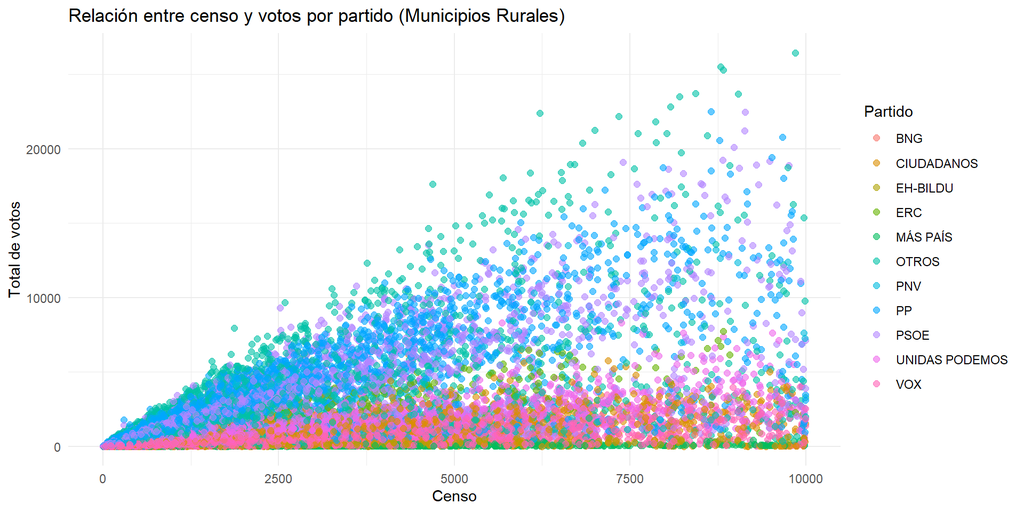

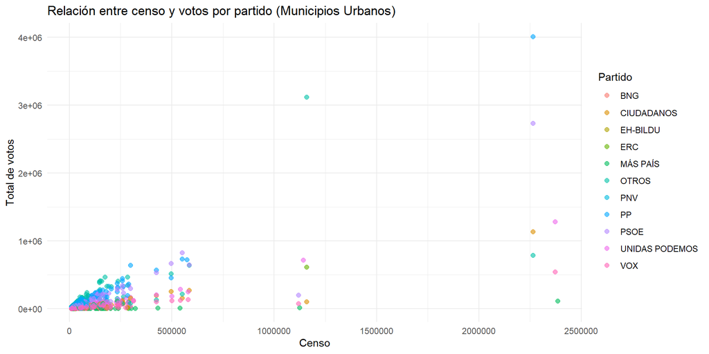

## Pregunta 5: ¿Cómo calibrar el error de las encuestas?

```r
# Crear una lista maestra de partidos
todos_partidos <- tidy_surveys |>
  distinct(partido) |>
  bind_rows(datos_elecciones_tidy |> distinct(partido)) |>
  distinct(partido)

# Generar combinaciones completas de año, mes y partido
combinaciones_completas <- expand_grid(
  anno = unique(datos_elecciones_tidy$anno),
  mes = unique(datos_elecciones_tidy$mes),
  partido = todos_partidos$partido)

# Agregar votos reales a nivel nacional
votos_nacionales <- datos_elecciones_tidy |>
  group_by(anno, mes, partido) |>
  summarise(total_votos = sum(votos, na.rm = TRUE), .groups = "drop") |>
  right_join(combinaciones_completas, by = c("anno", "mes", "partido")) |>
  mutate(
    total_votos = replace_na(total_votos, 0),  # Rellenar valores faltantes con 0
    voto_real_pct = total_votos / sum(total_votos) * 100  # Calcular porcentaje de votos
  )

# Preparar tidy_surveys: extraer año y mes de date_elec
tidy_surveys <- tidy_surveys |>
  mutate(
    anno = year(date_elec),
    mes = month(date_elec)
  )

# Calcular intención de voto y error calibrado
calibrated_data <- tidy_surveys |>
  mutate(
    encuesta_pct = (count / size) * 100  # Convertir intención de voto a porcentaje
  ) |>
  full_join(
    votos_nacionales,
    by = c("anno", "mes", "partido")  # Unir por año, mes y partido
  ) |>
  mutate(
    encuesta_pct = replace_na(encuesta_pct, 0),  # Rellenar valores faltantes con 0
    voto_real_pct = replace_na(voto_real_pct, 0),  # Rellenar valores faltantes con 0
    error_abs = abs(voto_real_pct - encuesta_pct),  # Error absoluto
    error_calibrado = if_else(voto_real_pct > 0, error_abs / voto_real_pct * 100, NA_real_)  # Evitar divisiones por 0
  )

# Promediar el error calibrado por partido
calibrated_error_summary <- calibrated_data |>
  group_by(partido) |>
  summarise(
    avg_error_calibrado = mean(error_calibrado, na.rm = TRUE),
    max_error_calibrado = max(error_calibrado, na.rm = TRUE),
    min_error_calibrado = min(error_calibrado, na.rm = TRUE),
    .groups = "drop"
  )
```

# Código y gráfica relacionada

```r
print(calibrated_error_summary)
```

```
# A tibble: 11 × 4
   partido        avg_error_calibrado max_error_calibrado min_error_calibrado
   <chr>                        <dbl>               <dbl>               <dbl>
 1 BNG                          2207.              11917.             40.3
 2 CIUDADANOS                    100                 100             100
 3 EH-BILDU                      100                 100             100
 4 ERC                          1912.              11276.              1.99
 5 MÁS PAÍS                      100                 100             100
 6 OTROS                         723.              10998.              0.0666
 7 PNV                           100                 100             100
 8 PP                           2392.              32282.              7.52
 9 PSOE                         3774.              48863.              2.15
10 UNIDAS PODEMOS                100                 100             100
11 VOX                           284.               1622.              8.19
```

## Pregunta 6: ¿Qué casas encuestadoras acertaron más y cuáles se desviaron más de los resultados?

```r
# Resumir los votos reales a nivel nacional
votos_resumidos <- datos_elecciones_tidy |>
  group_by(anno, mes, partido) |>
  summarise(
    total_votos = sum(votos, na.rm = TRUE),
    .groups = "drop"
  ) |>
  group_by(anno, mes) |>
  mutate(
    voto_real_pct = total_votos / sum(total_votos) * 100  # Porcentaje de votos por partido
  ) |>
  ungroup()

# Resumir intención de voto por encuesta
encuestas_resumidas <- tidy_surveys |>
  mutate(
    anno = year(date_elec),
    mes = month(date_elec)
  ) |>
  group_by(anno, mes, partido) |>
  summarise(
    encuesta_pct = sum(count, na.rm = TRUE) / sum(size, na.rm = TRUE) * 100,  # Porcentaje de intención de voto
    .groups = "drop"
  )

# Calcular el error sin realizar joins
errores_calibrados <- votos_resumidos |>
  left_join(encuestas_resumidas, by = c("anno", "mes", "partido")) |>
  filter(!is.na(encuesta_pct)) |>  # Filtrar partidos que tienen datos en ambas tablas
  summarise(
    partido = partido,
    anno = anno,
    mes = mes,
    error_abs = abs(voto_real_pct - encuesta_pct),  # Error absoluto
    error_calibrado = abs(voto_real_pct - encuesta_pct) / voto_real_pct * 100  # Error calibrado
  )

# Resumir el error calibrado por partido
resumen_errores <- errores_calibrados |>
  group_by(partido) |>
  summarise(
    avg_error_calibrado = mean(error_calibrado, na.rm = TRUE),
    max_error_calibrado = max(error_calibrado, na.rm = TRUE),
    min_error_calibrado = min(error_calibrado, na.rm = TRUE),
    .groups = "drop"
  )


#GRAFICOS
encuestas_vs_resultados <- tidy_surveys |>
  mutate(
    anno = year(date_elec),  # Extrae el año de la fecha
    mes = month(date_elec)   # Extrae el mes de la fecha
  ) |>
  inner_join(datos_elecciones_tidy, by = c("anno", "mes", "partido")) |>
  mutate(
    encuesta_pct = (count / size) * 100,  # Porcentaje de intención de voto
    voto_real_pct = (votos / sum(votos)) * 100,  # Porcentaje de votos reales
    error_abs = abs(encuesta_pct - voto_real_pct)  # Error absoluto
  )

precision_por_encuestadora <- encuestas_vs_resultados |>
  group_by(pollster) |>
  summarise(media_error_abs = mean(error_abs, na.rm = TRUE)) |>
  arrange(media_error_abs)

grafica6 <- ggplot(precision_por_encuestadora, aes(x = reorder(pollster, media_error_abs), y = media_error_abs)) +
  geom_bar(stat = "identity", fill = "steelblue") +
  coord_flip() +
  labs(
    title = "Error Absoluto Promedio por Encuestadora",
    x = "Casa Encuestadora",
    y = "Error Absoluto Promedio"
  ) +
  theme_minimal() +
  theme(
    axis.text.y = element_text(size = 6) # Reduce el tamaño del texto en el eje Y
  )
```

# Código y gráfica relacionada

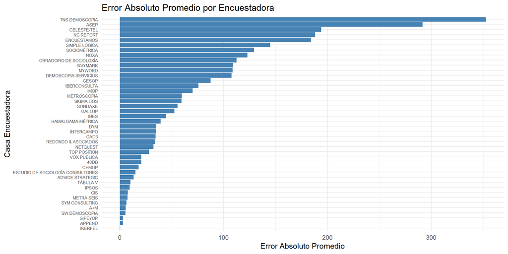

## Pregunta 7: ¿Existe una relación entre la precisión de las encuestas y el tiempo de trabajo de campo (días de recogida de datos)?

```r
# Convertir field_duration a número de días utilizando lubridate
encuestas_con_resultados <- tidy_surveys |>
  mutate(
    duration_days = as.numeric(as.duration(field_duration) / ddays(1)) # Convertir a duración y luego a días
  ) |>
  inner_join(datos_elecciones_tidy, by = c("partido" = "partido")) |>
  mutate(
    error = abs(count - votos) / votos * 100 # Calcular error porcentual
  )

# Agrupar las encuestas por duración de días y calcular el error promedio
resumen_error <- encuestas_con_resultados |>
  group_by(duration_days) |>
  summarise(
    error_avg = mean(error, na.rm = TRUE), # Promedio del error
    .groups = "drop"
  )

#GRAFICAS

grafica7 <- ggplot(resumen_error, aes(x = duration_days, y = error_avg)) +
  geom_line(color = "#1f78b4", size = 1.2) +
  geom_point(color = "#33a02c", size = 3, shape = 21, fill = "white") +
  labs(
    title = glue("Relación entre duración del trabajo de campo y precisión ({min(as.numeric(substr(tidy_surveys$date_elec, 1, 4)))}-{max(as.numeric(substr(tidy_surveys$date_elec, 1, 4)))})"),
    subtitle = "Análisis de cómo el tiempo dedicado afecta la precisión de las encuestas",
    x = "Días de trabajo de campo",
    y = "Error promedio ",
    caption = "Fuente: Encuestas históricas 2008-2019"
  ) +
  theme_minimal(base_size = 14) +
  theme(
    plot.title = element_text(size = 18, face = "bold", hjust = 0.5),
    plot.subtitle = element_text(size = 12, hjust = 0.5),
    axis.title = element_text(size = 14, face = "bold"),
    axis.text = element_text(size = 12),
    panel.grid.major = element_line(color = "gray90"),
    panel.grid.minor = element_blank(),
    plot.caption = element_text(size = 10, face = "italic", hjust = 1),
    plot.background = element_rect(fill = "white", color = "white"),
    panel.background = element_rect(fill = "white", color = "white")
  ) +
  scale_x_continuous(breaks = seq(0, max(resumen_error$duration_days, na.rm = TRUE), by = 5))
```

# Código y gráfica relacionada

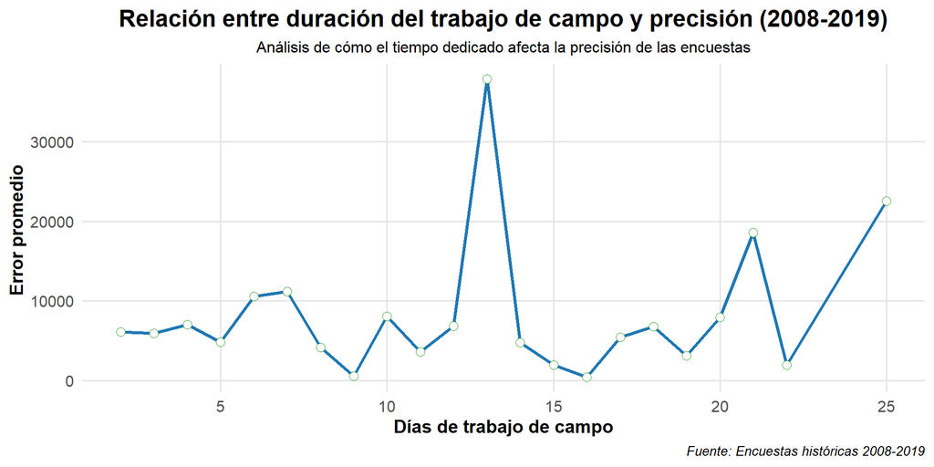

## Pregunta 8: ¿Cómo evolucionaron las preferencias hacia los partidos nacionalistas/regionalistas en comparación con los partidos nacionales durante el período 2008-2019?

```r
partidos_clasificados <- datos_elecciones_tidy |>
  mutate(
    grupo_partido = case_when(
      partido %in% c("EAJ-PNV", "BNG", "CIU", "ERC", "EH-BILDU") ~ "NACIONALISTA/REGIONALISTA",
      partido %in% c("PSOE", "PP", "C's", "VOX", "PODEMOS", "MÁS PAÍS", "PODEMOS-COM", "PODEMOS-EUP", "PODEMOS-IU-EQUO") ~ "NACIONAL",
      TRUE ~ NA_character_)
  ) |>
  filter(!is.na(grupo_partido) & anno >= 2008 & anno <= 2019)

# Agrupamos por año y grupo de partido. Además, sumamos los votos
datos_agrupados <- partidos_clasificados |>
  group_by(anno, grupo_partido) |>
  summarise(total_votos = sum(votos, na.rm = TRUE), .groups = "drop")

# Calculamos el porcentaje de votos por grupo dentro de cada año
porcentajes <- datos_agrupados |>
  group_by(anno) |>
  mutate(porcentaje_votos = (total_votos / sum(total_votos)) * 100) |>
  ungroup()

#GRAFICOS

grafico8 <- porcentajes |>
  ggplot(aes(x = anno, y = porcentaje_votos, color = grupo_partido, group = grupo_partido)) +
  geom_line(size = 0.75) +
  geom_point(size = 2) +
  geom_text(aes(label = paste0(round(porcentaje_votos, 1), "%")),
            position = position_nudge(y = 5), size = 3) +  # Añade las etiquetas con el porcentaje y su posicion y tamaño
  labs(
    title = "Evolución de las preferencias por tipo de partido (2008-2019)",
    x = "Año",
    y = "Porcentaje de votos",
    color = "Tipo de partido"
  ) +
  theme_minimal() +
  scale_color_manual(values = c(
    "NACIONALISTA/REGIONALISTA" = "#FF5733",  # Naranja
    "NACIONAL" = "#1F77B4"                   # Azul
  )) +
  scale_x_continuous(breaks = seq(2008, 2019, 1))  # Asegura que los años sean enteros y aparezcan de uno en uno
```

# Código y gráfica relacionada

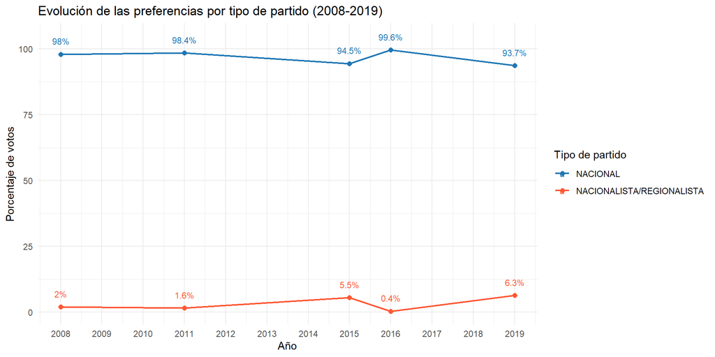

## Pregunta 9: ¿Cómo evolucionó la proporción de votos de partidos como Podemos y Vox desde su aparición? ¿Qué provincias votaron más a Podemos en 2019? ¿Y a Vox?

```r
partidos_emergentes <- datos_elecciones_tidy |>
  filter(partido %in% c("UNIDAS PODEMOS", "VOX") & anno >= 2014) |>
  mutate(partido = case_when(
    partido %in% c("UNIDAS PODEMOS") ~ "UNIDAS PODEMOS",
    TRUE ~ partido
  ))

# Agrupamos por año y partido, y calculamos el total de votos
datos_agrupados9 <- partidos_emergentes |>
  group_by(anno, partido) |>
  summarise(total_votos = sum(votos, na.rm = TRUE), .groups = "drop")

# Calculamos el porcentaje de votos por partido dentro de cada año
porcentajes9 <- datos_agrupados9 |>
  group_by(anno) |>
  mutate(porcentaje_votos = (total_votos / sum(total_votos)) * 100) |>
  ungroup()

# Filtramos las elecciones de 2019 y los partidos Unidas Podemos y Vox
partidos_2019 <- datos_elecciones_tidy |>
  filter(anno == 2019 & partido %in% c("UNIDAS PODEMOS", "VOX"))

# Extraemos el código de la provincia y calculamos los votos totales por provincia y partido
votos_provincia <- partidos_2019 |>
  mutate(codigo_provincia = substr(codigo_municipio, 4, 5)) |>  # Extrae el código de la provincia
  group_by(codigo_provincia, partido) |>
  summarise(total_votos = sum(votos, na.rm = TRUE), .groups = "drop")

# Determinamos el partido más votado por provincia
provincia_mas_votada <- votos_provincia |>
  pivot_wider(names_from = partido, values_from = total_votos, values_fill = 0) |>
  mutate(partido_mas_votado = case_when(
      `VOX` > `UNIDAS PODEMOS` ~ "VOX",
      `UNIDAS PODEMOS` > `VOX` ~ "UNIDAS PODEMOS",
      TRUE ~ NA_character_  # En caso de empate
    )
  )

#GRAFICAS

# Obtenemos el mapa base de España con el paquete mapSpain
mapa_provincias <- esp_get_prov()  # Obtiene las geometrías de las provincias

# Asociamos los datos de votos al mapa
mapa_provincias <- mapa_provincias |>
  mutate(codigo_provincia = codauto) |>  # Usamos el código de provincia para unir
  left_join(provincia_mas_votada, by = "codigo_provincia")

# Creamos el mapa con los colores asociados a los partidos
mapa_final <- ggplot(mapa_provincias) +
  geom_sf(aes(fill = partido_mas_votado), color = "white") +
  scale_fill_manual(values = c(
    "VOX" = "#008000",        # Verde para Vox
    "UNIDAS PODEMOS" = "#4B0082"  # Morado para Unidas Podemos
  ), na.value = "grey") +
  labs(
    title = "Provincias con más votos a Unidas Podemos o Vox (2019)",
    fill = "Partido más votado") +
  theme_minimal() +
  theme(axis.text = element_blank(), axis.ticks = element_blank())  # Eliminamos las coordenadas innecesarias

grafico9 <- porcentajes9 |>
  ggplot(aes(x = anno, y = porcentaje_votos, color = partido, group = partido)) +
  geom_line(size = 1.2) +
  geom_point(size = 2) +
  geom_text(
    aes(label = paste0(round(porcentaje_votos, 1), "%"),
        y = ifelse(partido == "UNIDAS PODEMOS", porcentaje_votos + 5, porcentaje_votos -5)), size = 3) +  # Ajusta la posición de las etiquetas
  labs(
    title = "Evolución Proporción de votos de Unidas Podemos y Vox (2014-2019)",
    x = "Año",
    y = "Porcentaje de votos",
    color = "Partido"
  ) +
  theme_minimal() +
  scale_color_manual(values = c(
    "UNIDAS PODEMOS" = "#4B0082",  # Morado
    "VOX" = "#008000"       # Verde
  )) +
  scale_x_continuous(breaks = seq(2014, 2019, 1))  # Asegura que los años sean enteros y vayan de uno en uno
```

# Código y gráfica relacionada

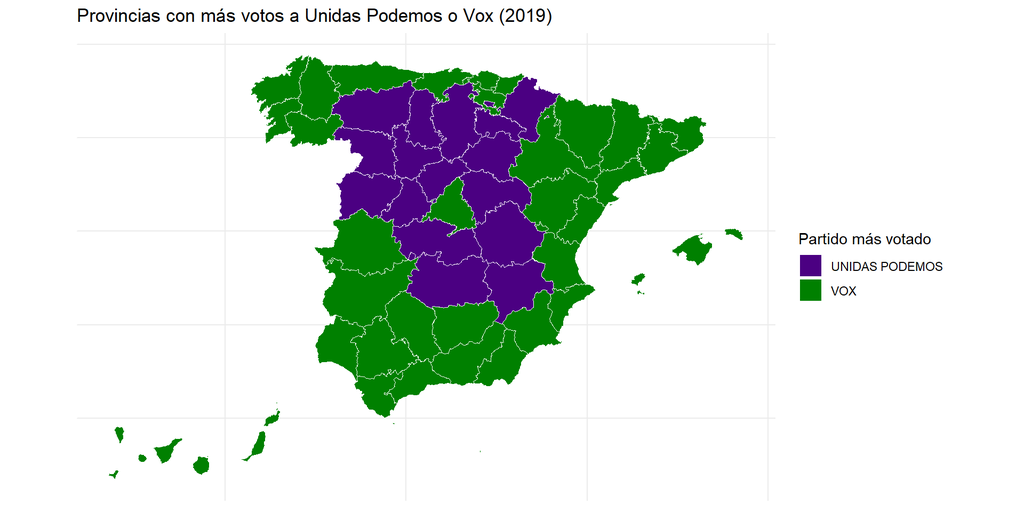

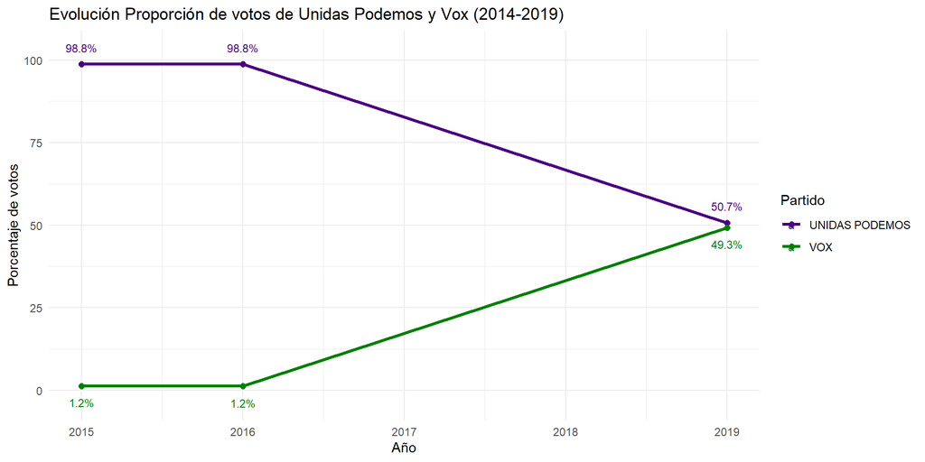

# Reflexiones y Desafíos

Hemos conseguido transformar datos en bruto en información limpia y estructurada, además de responder preguntas clave sobre tendencias electorales. Algunas ventajas y desafíos:

### Ventajas:

- Automatización del análisis con R.
- Visualizaciones personalizadas para interpretar patrones.

### Desafíos:

- Limpieza crucial para obtener resultados precisos.
- Interpretación de tendencias con datos históricos escasos.

# Sugerencias

- Ampliar el alcance del análisis.
- Mejorar la precisión de los datos.
- Explorar enfoques alternativos.
- Analizar el impacto de factores externos como redes sociales.
- Reforzar los criterios de las encuestas.
- Examinar el impacto de la demografía en los patrones de voto.